# Advanced shell scripting

Optional self-study content for week 7

Author

Affiliations

Jelmer Poelstra

[CFAES Bioinformatics Core, Ohio State University](https://go.osu.edu/bioinformatics-core)

[Dept. of Plant Pathology, Ohio State University](https://plantpath.osu.edu)

Published on

October 2, 2026

Page last modified

October 10, 2026

## 1 Introduction

This page covers additional shell scripting topics that build on the w7a and w7b lectures: command substitution, extracting parts of file paths, renaming files with loops, conditionals, `while` loops, and more. If you’re short on time, prioritize the first two sections (command substitution and extracting parts of file paths), which will be useful for one of the upcoming graded assignments.

### 1.1 Setting up

1. At https://ondemand.osc.edu, start a VS Code session in `/fs/ess/PAS3493/people/$USER`.
2. In the terminal, navigate to your `week07` dir.

Some of the examples and exercises use the `scripts/printname.sh` and `scripts/fastqc.sh` scripts that you wrote in w7a.

## 2 Command substitution

Command substitution allows you to use the **output of a command** inside another command — most commonly, to **store it in a variable**. This is especially useful in scripts and loops. Let’s see an example. As you know, the `date` command will print the current date and time:

```bash
date
```

```
Mon Oct  5 14:52:22 EDT 2026
```

If you try to store the output of `date` like below, it doesn’t work — instead, the literal string “date” is stored:

```bash
today=date
echo "$today"
```

```
date
```

To run a command and store its output, you need command substitution, where the command is wrapped inside **`$()`**:

```bash
today=$(date)
echo "$today"
```

```
Mon Oct  5 14:54:11 EDT 2026
```

A practical example of using command substitution is to **automatically** include the current date in a file name. “Automatically” means that the same command will work regardless of the date — for example, inside a script that you may run at any time.

Let’s first learn how to get the current date in a format that is suitable for file names. You can give `date` a format string that starts with a `+`, and `date +%F` will print the date in `YYYY-MM-DD` format and without the time:

```bash
date +%F
```

```
2026-10-05
```

- Let’s use that in a command substitution:

  ```bash
  # Store the current date in a variable:
  today=$(date +%F)

  # Use that variable in a file name:
  touch README_"$today".md
  ```

- Check if it worked:

  ```bash
  ls README_*
  ```

  ```
  README_2026-10-05.md
  ```

It is even possible to do this all in one go, by using the command substitution `$(date +%F)` directly in your `touch` command, rather than first assigning it to a variable:

```bash
touch README_"$(date +%F)".md
```

**TipOlder syntax for command substitution**

You may also come across an older syntax for command substitution that uses backticks, as in `` today=`date` ``. It does the same thing, but `$()` is easier to read, so we’ll stick to that.

#### Exercise 1: Command substitution

Say that you want to count and report the number of FASTQ files in a directory in a generalized, programmatic way — like inside a script.

1. Count and report the number of FASTQ files in `../garrigos/fastq/`:
   - Write a command that will count the number of FASTQ files in `../garrigos/fastq/`.
   - Use command substitution to store the result in a variable.
   - Use `echo` to print the following using the variable you created:

   ```
   The input dir has 44 files, now processing...
   ```

   **Click for some hints**
   - You can count the number of FASTQ files by piping the output of `ls` to `wc -l`.
   - Your final `echo` command should look something like this:

     ```bash
     echo "The input dir has $n_files files, now processing..."
     ```

     So, try to store the file count produced by the command in the variable `$n_files`.

   **Click for the solution**

   ```bash
   n_files=$(ls ../garrigos/fastq/*fastq.gz | wc -l)

   echo "The input dir has $n_files files, now processing..."
   ```

   ```
   The input dir has 44 files, now processing...
   ```

   **Note:** The variable is already inside a double-quoted string, so you don’t need to quote it separately. In fact, `echo "The input dir has "$n_files" files"` would *end* the quoted string right before the variable and start a new one after it, leaving the variable itself unquoted.
2. Adapt your commands to report the number of *samples* rather than files:

   ```
   The input dir has 22 samples, now processing...
   ```

   **Click for the solution**

   To count samples, only count the R1 files:

   ```bash
   n_samples=$(ls ../garrigos/fastq/*_R1.fastq.gz | wc -l)

   echo "The input dir has $n_samples samples, now processing..."
   ```

   ```
   The input dir has 22 samples, now processing...
   ```

**NoteDoing arithmetic with `$(( ))`**

A construct that looks similar to command substitution is `$(( ))`, which does arithmetic rather than running a command. For example, an alternative way to count the number of samples in Exercise 1 is to divide the number of FASTQ files by 2:

```bash
n_files=$(ls ../garrigos/fastq/*fastq.gz | wc -l)
n_samples=$(( n_files / 2 ))
echo "$n_samples"
```

```
22
```

Inside `$(( ))`, you can refer to variables without the `$`, and you can use `+`, `-`, `*`, and `/`. Note that Bash can only do *integer* arithmetic: any decimal part is simply discarded, so `$(( 45 / 2 ))` gives `22`.

## 3 Commands to extract parts of paths

In loops and other contexts where you are working with file names programmatically, it is common to have a file path from which you want to extract just the “file name part” and/or the “directory part”:

| Path | Directory part | File name part |
| --- | --- | --- |
| `data/fastq/sample1_R1.fastq` | `data/fastq` | `sample1_R1.fastq` |
| `../garrigos/fastq/S63_R1.fastq.gz` | `../garrigos/fastq` | `S63_R1.fastq.gz` |

Extracting these parts can be done with the `dirname` and `basename` commands. Running `dirname` on a path will return the directory part of that path:

```bash
dirname ../garrigos/fastq/S63_R1.fastq.gz
```

```
../garrigos/fastq
```

Similarly, `basename` will strip any directories and just return the file name:

```bash
basename ../garrigos/fastq/S63_R1.fastq.gz
```

```
S63_R1.fastq.gz
```

You can optionally provide a **suffix to strip** from the file name, simply as a second argument to `basename`. For example, to strip the `.fastq.gz` suffix:

```bash
basename ../garrigos/fastq/S63_R1.fastq.gz .fastq.gz
```

```
S63_R1
```

In practice, `basename` is often used in scripts to **define output file paths** that have the same file names as the input files, but are in a different dir. You’ll need this with programs that make you specify output file *names* rather than just an output dir.

For example, the fictional program `trimmer2` requires the arguments `--out1` and `--out2` to specify the output file names. Create this script as `scripts/trimmer2.sh`:

```
scripts/trimmer2.sh
```

```bash
#!/bin/bash
set -euo pipefail

# Copy the placeholder variables
R1_in="$1"
R2_in="$2"
outdir="$3"

# Define the output file names: we want the input and output file names
# to be the same - they should just be in different dirs:
R1_out="$outdir"/$(basename "$R1_in")
R2_out="$outdir"/$(basename "$R2_in")

# Mock-run a fictional program that takes output file paths as arguments:
echo trimmer2 --in1 "$R1_in" --in2 "$R2_in" --out1 "$R1_out" --out2 "$R2_out"
```

Because the script “runs” `trimmer2` with `echo`, running it will simply print the command with the output file paths filled in. Note that these have the same file names as the input files, but are in the output dir specified by the third argument:

```bash
bash scripts/trimmer2.sh ../garrigos/fastq/S63_R*.fastq.gz results/trim
```

```
trimmer2 --in1 ../garrigos/fastq/S63_R1.fastq.gz --in2 ../garrigos/fastq/S63_R2.fastq.gz --out1 results/trim/S63_R1.fastq.gz --out2 results/trim/S63_R2.fastq.gz
```

**NoteGetting the full path with `realpath` *(Click to expand)**

A related command is `realpath`, which turns a relative path into an **absolute (full) path**:

```bash
realpath ../garrigos/fastq/S63_R1.fastq.gz
```

```
/fs/ess/PAS3493/people/jane/garrigos/fastq/S63_R1.fastq.gz
```

This can be useful when you want to record exactly which files were used — for example, by printing the full input file paths in a script’s log output, which will then be unambiguous regardless of where the script was run from.

#### Exercise 2: `basename` and `dirname`

Predict the output of each of the following commands, and then run them to check your predictions:

```bash
basename ../garrigos/fastq/S63_R1.fastq.gz .fastq
```

```bash
dirname S63_R1.fastq.gz
```

```bash
basename ../garrigos/fastq/
```

**Click for the solution**

1. `basename` removes the suffix only if the file name *ends* in it. `.fastq` occurs in the file name, but not at its end, so nothing is removed — and you don’t get an error or warning either:

   ```
   S63_R1.fastq.gz
   ```

2. A file name without any dirs refers to a file in your working dir, so `dirname` returns `.`, the shorthand for the working dir:

   ```
   .
   ```

3. `basename` doesn’t check whether a path points to a file or a dir: it simply returns the last part of the path (ignoring a trailing `/`):

   ```
   fastq
   ```

## 4 Renaming files with loops

Sometimes, you need to rename many files in a systematic/repetitive way. This is relatively common with omics data files, as you will often have separate files for each sample, and you may have many dozens of samples.

Manually renaming these one-by-one is tedious, error-prone, and not reproducible. There are many different ways to rename many files in a programmatic way in the shell — though admittedly, none as easy as one might have hoped. Here, we’ll use the `basename` command and a `for` loop.

### 4.1 Create a set of dummy files to work with

Start with creating some dummy files that represent alignments (the results of aligning reads in FASTQ files to a reference genome, stored in `.sam` or `.bam` files)[^1]:

```bash
# Create the sandbox dir (if it doesn't already exist)
mkdir -p sandbox
# Use brace expansion to create 50 dummy SAM files:
touch sandbox/sample{01..50}.sam
```

Check the names of the files you created and how many there are:

```bash
ls sandbox/*.sam
```

```
sandbox/sample01.sam
sandbox/sample02.sam
sandbox/sample03.sam
sandbox/sample04.sam
# [...output truncated...]
```

```bash
ls sandbox/*.sam | wc -l
```

```
50
```

Now, say that you noticed these files somehow ended up with the wrong file extension: they are saved as `.sam` (SAM files) but are really `.bam` (BAM files). You’ll have to rename them before moving on to the next step in your analysis.

### 4.2 Rename a single file using variables

When renaming files in a loop, you will typically use variables to store the original and new file paths. Let’s practice that first with a single file, before we put it in a loop.

- Your old file path is:

  ```bash
  old_path=sandbox/sample01.sam
  ```

- You extract the file ID from the old path using `basename` and store it in a variable:

  ```bash
  # Save the filename without the extension using command substitution:
  file_id=$(basename "$old_path" .sam)

  # Check that it worked:
  echo "$file_id"
  ```

  ```
  sample01
  ```

- Now, you can save the new file path in a variable, using that file ID:

  ```bash
  new_path=sandbox/"$file_id".bam

  # Check that it worked:
  echo "$new_path"
  ```

  ```
  sandbox/sample01.bam
  ```

- And using these variables, the `mv` command to do the renaming would be:

  ```bash
  # (We'll do this in a loop later, so for now, don't actually run it)
  mv -v "$old_path" "$new_path"
  ```

**TipAlternative ways to build the new path *(Click to expand)**

- We used a two-step approach above for clarity, but you can also do it in one step with `basename`:

  ```bash
  new_path=sandbox/$(basename "$old_path" .sam).bam
  ```

- Alternatively, you could go a different route and use parameter expansion:

  ```bash
  new_path=${old_path/.sam/.bam}
  ```

### 4.3 Loop over all files

Now, we’ll loop over all files and add the renaming code inside the loop. Before actually renaming, let’s do a “dry run” by putting `echo` in front of `mv`, which prints the commands instead of executing them. Because the commands contain variables, this is a good way to check that they look as intended:

```bash
for old_path in sandbox/*.sam; do
    # Build the new file path:
    file_id=$(basename "$old_path" .sam)
    new_path=sandbox/"$file_id".bam

    # Rename the file:
    echo mv -v "$old_path" "$new_path"
done
```

```
mv -v sandbox/sample01.sam sandbox/sample01.bam
mv -v sandbox/sample02.sam sandbox/sample02.bam
mv -v sandbox/sample03.sam sandbox/sample03.bam
mv -v sandbox/sample04.sam sandbox/sample04.bam
# [...output truncated...]
```

Finally, actually perform the renaming by removing `echo`:

```bash
for old_path in sandbox/*.sam; do
    # Build the new file path:
    file_id=$(basename "$old_path" .sam)
    new_path=sandbox/"$file_id".bam

    # Rename the file:
    mv -v "$old_path" "$new_path"
done
```

```
renamed 'sandbox/sample01.sam' -> 'sandbox/sample01.bam'
renamed 'sandbox/sample02.sam' -> 'sandbox/sample02.bam'
renamed 'sandbox/sample03.sam' -> 'sandbox/sample03.bam'
renamed 'sandbox/sample04.sam' -> 'sandbox/sample04.bam'
# [...output truncated...]
```

`mv` will **silently overwrite** an existing file with the same name as the new path. This is another reason to always check your renaming commands with `echo` first, especially when the new names are shorter or less unique than the old ones. You can also use `mv -n` (“no-clobber”), which will never overwrite an existing file.

#### Exercise 3: Renaming files

1. What would happen if you ran the final renaming loop above a second time? Predict the output, and then run the loop again to check. *Hint: recall the third loop in w7b Exercise 1.*

   **Click for the solution**

   There are no `.sam` files left, so the glob doesn’t match anything. Therefore, the loop runs once, with `$old_path` containing the literal string `sandbox/*.sam`.

   `mv` then fails because no file with that name exists, so no harm is done:

   ```
   mv: cannot stat 'sandbox/*.sam': No such file or directory
   ```

2. A labmate builds the new file path with parameter expansion instead: `new_path="${old_path/sam/bam}"`. What would the new path be for `sandbox/sample01.sam`? Check your prediction with `echo`, and then fix the parameter expansion.

   **Click for the solution**

   The first match of `sam` is in `sample`, not in the extension!

   ```bash
   old_path=sandbox/sample01.sam
   echo "${old_path/sam/bam}"
   ```

   ```
   sandbox/bample01.sam
   ```

   Including the period in the search pattern fixes this: `new_path="${old_path/.sam/.bam}"`.

## 5 Conditionals

With conditionals like `if` statements, you can **run one or more commands only when a condition is met**. You can additionally run a different set of commands when the condition is *not* met.

### 5.1 A first `if` statement

Let’s start with a simple example that you can run in the terminal. First, assign a value to a variable `fruit`:

```bash
fruit=apple
```

Next, use an `if` statement to print a message only if `$fruit` is “apple”:

```bash
if [[ "$fruit" == "apple" ]]; then
    echo "It's an apple!"
fi
```

```
It's an apple!
```

Now, assign a different value to `fruit`, and run the same `if` statement again:

```bash
fruit=banana

if [[ "$fruit" == "apple" ]]; then
    echo "It's an apple!"
fi
```

This time, nothing is printed, because the condition was not met, so the `echo` line was skipped. Here’s how that works:

- After `if` comes the **condition**, where the double square brackets `[[ ]]` represent a *test*[^2], and `==` tests whether the text on either side is identical.
- After `then`, you put one or more lines with commands that should run **only if** the condition is true.
- The `if` statement ends with `fi`[^3].

**WarningSpaces and double `==`**

- The spaces bordering the brackets on the inside are necessary: `[["$fruit" == "apple"]]` would fail!
- The same goes for the spaces around `==`, and leaving those out is even more treacherous: `[[ "$fruit"=="apple" ]]` will not give an error, but will always be true, regardless of the value of `$fruit`.
- A double `==` is common in programming to **test for equality**, as opposed to a single `=`, which is used for variable assignment.

### 5.2 Adding an `else` clause

To run alternative command(s) when the condition is *not* met, add an `else` clause:

```bash
fruit=banana

if [[ "$fruit" == "apple" ]]; then
    echo "It's an apple!"
else
    echo "It's not an apple, it's a $fruit."
fi
```

```
It's not an apple, it's a banana.
```

So, exactly one of the two `echo` lines is always run. In general, the syntax of an `if` statement is:

```bash
if <test>; then
    # Command(s) to run if the condition is true
else
    # Command(s) to run if the condition is false (optional)
fi
```

### 5.3 Conditionals in shell scripts

`if` statements are especially useful in shell scripts. You may, for instance, want to check that all inputs are correct, and exit with an informative error if that’s not the case. While doing this adds complexity to your shell script, it can be worth it because:

- The sooner you stop a script from running when there are such problems, the better.
- If you pass erroneous input to the program that your script runs, you may get confusing errors or, even worse, failure without any clear error message at all.

In the example below, an `if` statement checks whether the input file has a FASTQ file extension, and exits the script *if* it doesn’t:

```bash
if [[ "$fastq" == *.fastq.gz ]]; then
    echo "Processing FASTQ file $fastq..."
    # [Commands to process the FASTQ file...]
else
    echo "Error: input file $fastq does not have a .fastq.gz extension!"
    exit 1
fi
```

Note that `*.fastq.gz` is *not* quoted. When the right-hand side of `==` is unquoted, it is treated as a pattern with the same wildcards as globbing, so the test is true for any value of `$fastq` that ends in `.fastq.gz`. (With quotes, the test would only be true for a file literally named `*.fastq.gz`!)

When used inside a script, the `exit` command will stop the execution of the script. With `exit 1`, the *exit status* of our script is 1: an exit status of 0 means success — any other integer, including 1, means failure. (Don’t run `exit` directly in your terminal, though: that will exit your shell and close the terminal!)

### 5.4 String comparisons

The above test, `"$fastq" == *.fastq.gz`, was an example of a string comparison, where “string” is the programming term for text (as opposed to numbers). The two main string comparisons you can make are:

| String comparison | Evaluates to true (condition is met) if |
| --- | --- |
| `str1 == str2` | Strings `str1` and `str2` are identical[^4] |
| `str1 != str2` | Strings `str1` and `str2` are different |

### 5.5 Integer (number) comparisons

| Integer comparisons | Evaluates to true if |
| --- | --- |
| `int1 -eq int2` | Integers `int1` and `int2` are equal |
| `int1 -ne int2` | Integers `int1` and `int2` are not equal |
| `int1 -lt int2` | Integer `int1` is less than `int2` (`-le` for less than or equal to) |
| `int1 -gt int2` | Integer `int1` is greater than `int2` (`-ge` for greater than or equal to) |

Why these odd-looking operators instead of `<` (smaller than) and `>` (greater than)? Inside `[[ ]]`, `<` and `>` compare strings *alphabetically*, so for example, `[[ 10 < 9 ]]` is true, because “1” comes before “9”!

Bash can only compare integers: `[[ 2.5 -gt 2 ]]` will produce an error.

It can be a good idea to test at the beginning of a script whether the **correct number of arguments** were passed to it, and simply exit if that’s not the case. This can be done easily thanks to the `$#` variable, which, as you saw in w7a, contains the number of arguments that were passed to a script:

```bash
if [[ "$#" -ne 2 ]]; then
    echo "Error: wrong number of arguments"
    echo "You provided $# arguments, while 2 are required."
    echo "Usage: printname.sh <first-name> <last-name>"
    exit 1
fi
```

**TipAnother integer comparison example *(Click to expand)**

Say you want to run a program but the specifics of running it (e.g., some settings) depend on how many samples you run the program with.

With the number of samples determined from the number of lines in a hypothetical file `samples.txt` and stored in a variable `$n_samples`, you can test if the number is greater than 9 as follows:

```bash
# Store the number of samples in variable $n_samples:
n_samples=$(cat samples.txt | wc -l)

# With '-gt 9', the if statement tests whether the number of samples is greater than 9:
if [[ "$n_samples" -gt 9 ]]; then
    # Commands to run if nr of samples >9:
    echo "Processing files with algorithm A"
else
    # Commands to run if nr of samples is <=9:
    echo "Processing files with algorithm B"
fi
```

### 5.6 File tests

Finally, you can test whether files or dirs exist (and more):

| File/dir test | Evaluates to true if |
| --- | --- |
| `-f file` | `file` exists and is a regular file (not a dir) |
| `-d dir` | `dir` exists and is a directory |
| `-s file` | `file` exists and is not empty |

For example, the code below tests whether an input file exists using the file test **`-f`** and if it does *not* (hence the **`!`**), it will stop the execution of the script:

```bash
# '-f' is true if the file exists, so '! -f' is true if the file doesn't exist
if [[ ! -f "$fastq_file" ]]; then
    echo "Error: Input file $fastq_file not found!"
    exit 1
fi
```

**NoteTesting for multiple conditions at once with `&&` and `||` *(Click to expand)**

To test for multiple conditions at once, use the `&&` (“and”) and `||` (“or”) shell operators — for example:

- If the number of samples is less than 100 **and** at least 50 (i.e. 50-99):

  ```bash
  if [[ "$n_samples" -lt 100 && "$n_samples" -ge 50 ]]; then
      # Commands to run if the number of samples is 50-99
  fi
  ```

- If either one of two FASTQ files doesn’t exist:

  ```bash
  if [[ ! -f "$fastq_R1" || ! -f "$fastq_R2" ]]; then
      # Commands to run if either file doesn't exist - probably report error & exit
  fi
  ```

#### Exercise 4: Number of arguments

You will add the `if` statement from above, which tests whether the correct number of arguments were passed, to your `printname.sh` script.

**Click to see the `printname.sh` script from w7a**

```
scripts/printname.sh
```

```bash
#!/bin/bash
set -euo pipefail

first_name="$1"
last_name="$2"

echo "This script will print a first and a last name"
echo "First name: $first_name"
echo "Last name: $last_name"
```

1. First, think about *where* in the script the `if` statement should go. What would happen when you run the script with only 1 argument if you placed the `if` statement after the lines that copy `$1` and `$2`?

   **Click for the solution**

   The `if` statement should come before you copy the variables to `first_name` and `last_name`, otherwise you get the “unbound variable error” before your descriptive custom error, when you pass 0 or 1 arguments to the script.
2. Add the `if` statement to your script, and run the script consecutively with 1, 2, and 3 arguments. Recall what happened in the w7a exercise when you ran this script with the wrong number of arguments. For which of these runs does the `if` statement make the biggest difference?

   **Click for the solution**

   The final script:

   ```
   scripts/printname.sh
   ```

   ```bash
   #!/bin/bash
   set -euo pipefail

   if [[ "$#" -ne 2 ]]; then
       echo "Error: wrong number of arguments"
       echo "You provided $# arguments, while 2 are required."
       echo "Usage: printname.sh <first-name> <last-name>"
       exit 1
   fi

   first_name="$1"
   last_name="$2"

   echo "This script will print a first and a last name"
   echo "First name: $first_name"
   echo "Last name: $last_name"
   ```

   Run it with different numbers of arguments:

   ```bash
   bash scripts/printname.sh Jelmer
   ```

   ```
   Error: wrong number of arguments
   You provided 1 arguments, while 2 are required.
   Usage: printname.sh <first-name> <last-name>
   ```

   ```bash
   bash scripts/printname.sh Jelmer Poelstra
   ```

   ```
   This script will print a first and a last name
   First name: Jelmer
   Last name: Poelstra
   ```

   ```bash
   bash scripts/printname.sh Jelmer Wijtze Poelstra
   ```

   ```
   Error: wrong number of arguments
   You provided 3 arguments, while 2 are required.
   Usage: printname.sh <first-name> <last-name>
   ```

   So, the check helps most when there are *too many* arguments. Without it, the script would silently print the wrong last name (`Wijtze`), whereas with too few arguments, `set -u` would already have stopped the script, albeit with a less informative `$2: unbound variable` error.

#### Exercise 5: Check the input file

In w7b, you saw that if a glob doesn’t match any files, a loop will still run once, with the literal glob pattern as the “file name”. If such a loop calls one of your scripts, the script receives a “file” that doesn’t exist, such as `../garrigos/fastq/*_R3.fastq.gz`. Input files can also simply be misspelled or have the wrong path.

Rather than letting the program inside your script fail with a confusing error, or fail silently, it’s better for the script itself to check that its input exists.

Here, you will add an `if` statement to your `scripts/fastqc.sh` script that checks whether the input FASTQ file exists.

1. First, think about *where* in the script this check should go.

   **Click for the solution**

   The check should go right after copying the placeholder variables, and before the remaining code: *the sooner you stop a script when there’s a problem, the better* — here, for example, there’s no point in creating the output dir for a run that will fail.
2. Add the `if` statement to your script. If the input file doesn’t exist, it should print an informative error message and exit with exit status 1.

   **Click for the solution**

   ```
   scripts/fastqc.sh (excerpt)
   ```

   ```bash
   # Copy the placeholder variables
   fastq="$1"
   outdir="$2"

   # Check that the input file exists
   if [[ ! -f "$fastq" ]]; then
       echo "Error: Input file $fastq not found!"
       exit 1
   fi
   ```

3. Test your script by passing an input file name with a typo, like `../garrigos/fastq/S63_R1.fastq.g`.

   **Click for the solution**

   ```bash
   bash scripts/fastqc.sh ../garrigos/fastq/S63_R1.fastq.g results/fastqc
   ```

   ```
   Error: Input file ../garrigos/fastq/S63_R1.fastq.g not found!
   ```

4. Would your check also catch the following problems? Predict, and then test it:
   1. The input is a dir instead of a file: `bash scripts/fastqc.sh ../garrigos/fastq results/fastqc`
   2. The input file is empty: `touch empty.fastq.gz` and then `bash scripts/fastqc.sh empty.fastq.gz results/fastqc`

   How could you modify your script to also catch (b)?

   **Click for the solution**
   1. Yes: `-f` is only true for regular files, not for dirs.
   2. No: `empty.fastq.gz` exists and is a regular file, so FastQC would be run and fail with a confusing error.

   To also catch (b), add a second check with the `-s` test, which is only true for files that are not empty. Using a separate `if` statement makes for a more informative error message:

   ```
   scripts/fastqc.sh (excerpt)
   ```

   ```bash
   # Check that the input file exists and is not empty
   if [[ ! -f "$fastq" ]]; then
       echo "Error: Input file $fastq not found!"
       exit 1
   fi
   if [[ ! -s "$fastq" ]]; then
       echo "Error: Input file $fastq is empty!"
       exit 1
   fi
   ```

   (Replacing `-f` with `-s` wouldn’t work well: a dir is not “empty” in this sense, so `-s` would no longer catch (a).)

## 6 While loops

### 6.1 When are `while` loops useful?

A `for` loop iterates over a collection that you specify directly in the loop, such as a list of words or a glob pattern like `*fastq.gz`. A `while` loop instead runs **as long as a condition is true**.

In Bash, `while` loops are mostly used in combination with the `read` command, to loop over **each line in a file**. This is useful when:

- The items you want to loop over are **stored in a file**, such as a list of sample IDs, file paths, or accession numbers for files to download.
- Each line contains multiple pieces of information that **belong together**, like the rows of a metadata table with a sample ID, treatment, and time point.
- The items contain spaces: `read` reads entire lines, whereas a `for` loop over `$(cat file)` would split items at spaces.

### 6.2 A first `while` loop

To see how a `while` loop works, let’s create a file with one fruit per line:

```bash
touch fruits.txt
```

Open that file in the editor, enter the following lines, and make sure to press `Enter` after the last line (see the box below for why):

```
fruits.txt
```

```
apple
banana
plum
```

Now, loop over the lines in that file, and print each fruit:

```bash
while read -r fruit; do
    echo "Fruit: $fruit"
done < fruits.txt
```

```
Fruit: apple
Fruit: banana
Fruit: plum
```

So, the output is the same as that of the `for` loop `for fruit in apple banana plum` in w7b, but now, the collection of items comes from a file.

Here’s how that works:

- The `< fruits.txt` after `done` uses *input* redirection: just like `>` sends a command’s output *to* a file, `<` feeds a file’s contents *into* a command — here, the whole loop[^5].
- The condition after `while` is `read -r fruit`[^6]. Each time it is run, `read` reads **one line** from the input, and assigns it to the variable `fruit`.
- The lines between `do` and `done` are run for that line, using `$fruit` — just like in a `for` loop.
- Then, `read` is run again and reads the next line, and so on. Once there are no lines left, `read` “fails”, the condition is no longer true, and the loop stops.

**WarningThe last line needs a line break**

`read` only “succeeds” when it reaches the end of a line, which is marked by an invisible newline character. If the last line of a file isn’t followed by a newline, `read` fails on that line, and the loop **silently skips it**!

VS Code doesn’t add a final newline by default — so if `plum` was missing from your output, that’s why. You can make VS Code always add one by checking the **setting “Files: Insert Final Newline”.**

### 6.3 Looping over file names

Next, let’s loop over a list of FASTQ files. First, create a file with the paths to the two FASTQ files for one sample:

```bash
ls ../garrigos/fastq/S63_R*.fastq.gz > fastq_files.txt
```

```bash
cat fastq_files.txt
```

```
../garrigos/fastq/S63_R1.fastq.gz
../garrigos/fastq/S63_R2.fastq.gz
```

```bash
while read -r fastq_file; do
    echo "Processing file: $fastq_file"
    # More processing...
done < fastq_files.txt
```

```
Processing file: ../garrigos/fastq/S63_R1.fastq.gz
Processing file: ../garrigos/fastq/S63_R2.fastq.gz
```

### 6.4 Lines with multiple columns

We can also process each line of the file inside the `while` loop, like when we need to select a specific column. For this, we’ll use the Garrigós metadata file, which has one line per sample. First, create a copy of it without its header line (`tail -n +2` prints all lines starting from line 2):

```bash
tail -n +2 ../garrigos/meta/metadata.tsv > samples.tsv
head -n 3 samples.tsv
```

```
S82 10dpi   cathemerium
S75 10dpi   cathemerium
S79 10dpi   cathemerium
```

Now, loop over the lines in this file, and extract the first column (the sample ID) with `cut`:

```bash
while read -r my_line; do
    echo "Have read line: $my_line"
    sample_id=$(echo "$my_line" | cut -f 1)
    echo "Processing sample: $sample_id"
    # More processing...
done < samples.tsv
```

```
Have read line: S82 10dpi   cathemerium
Processing sample: S82
Have read line: S75 10dpi   cathemerium
Processing sample: S75
# [...output truncated...]
```

Alternatively, you can process the file with another command before it goes into the loop. Below, `cut` extracts the first column, and the `<(...)` construct (called “process substitution”) makes the output of that command available as if it were a file, so it can be redirected into the loop with `<`:

```bash
while read -r sample_id; do
    echo "Processing sample: $sample_id"
    # More processing...
done < <(cut -f 1 samples.tsv)
```

```
Processing sample: S82
Processing sample: S75
Processing sample: S79
Processing sample: S83
# [...output truncated...]
```

*(Note the space between the two `<`s, which is required:* *the first one is the redirection, and the second one is part of `<(...)`.)*

You can also extract columns directly by providing `read` with multiple variable names, as `read` will split each line at spaces and tabs:

```bash
while read -r sample_id time treatment; do
    echo "Processing sample: $sample_id (treatment: $treatment)"
    # More processing...
done < samples.tsv
```

```
Processing sample: S82 (treatment: cathemerium)
Processing sample: S75 (treatment: cathemerium)
# [...output truncated...]
```

Finally, we didn’t actually need to create the `samples.tsv` file at all: we can also remove the header line on the fly with process substitution, and read directly from the original metadata file:

```bash
while read -r sample_id time treatment; do
    echo "Processing sample: $sample_id (treatment: $treatment)"
    # More processing...
done < <(tail -n +2 ../garrigos/meta/metadata.tsv)
```

```
Processing sample: S82 (treatment: cathemerium)
Processing sample: S75 (treatment: cathemerium)
# [...output truncated...]
```

#### Exercise 6: While loops

1. Below, `read` gets only *two* variable names for the three columns in `samples.tsv`. What do you think the loop will print for the first sample? Predict, then run it to check.

   ```bash
   while read -r sample_id treatment; do
       echo "Sample: $sample_id / Treatment: $treatment"
   done < samples.tsv
   ```

   **Click for the solution**

   `read` assigns one column to each variable, but all *remaining* columns go into the last variable:

   ```
   Sample: S82 / Treatment: 10dpi   cathemerium
   # [...output truncated...]
   ```

   This is why the examples above needed the `time` variable even though they never use it: it is a placeholder that “absorbs” the second column, so that the third column ends up in `$treatment`. A common convention for such a “throwaway” variable is to name it `_`, as in `while read -r sample_id _ treatment; do`.
2. Write a `while` loop that prints the sample IDs of the `control` samples only.

   **Click for a hint**

   Use an `if` statement inside the `while` loop.

   **Click for the solution**

   ```bash
   while read -r sample_id time treatment; do
       if [[ "$treatment" == "control" ]]; then
           echo "$sample_id"
       fi
   done < samples.tsv
   ```

   ```
   S78
   S84
   S77
   S81
   S66
   S69
   S63
   ```

## 7 Miscellaneous

### 7.1 More on the `&&` and `||` operators

Above, you saw that multiple tests in `if` statements can be combined with `&&` and `||`. But these shell operators can be used to chain commands together in a more general way, as shown below. Here, a command “succeeds” if its exit status is 0, and “fails” otherwise. You can see the exit status of the last command you ran with the special variable `$?`:

```bash
ls nonexistent_dir
echo $?
```

```
ls: cannot access 'nonexistent_dir': No such file or directory
2
```

- Only if the first command **succeeds**, also run the second command:

  ```bash
  # Move into the data dir and if that succeeds, then list the files there:
  cd data && ls
  ```

  ```bash
  # Stage all changes => commit them => push the commit to remote:
  git add --all && git commit -m "Add README" && git push
  ```

- Only if the first command **fails**, also run the second command:

  ```bash
  # Exit the script if you can't change into the output dir:
  cd "$outdir" || exit 1
  ```

  ```bash
  # Print a warning if the input file is empty (or doesn't exist):
  [[ -s "$fastq" ]] || echo "Warning: input file $fastq is empty"
  ```

That last example works because a test like `[[ -s "$fastq" ]]` is simply a command with exit status 0 if the condition is true, and 1 if it is false. In fact, `if` works the same way: it runs the `then` block if the command after it has exit status 0.

### 7.2 Parameter expansion to provide default values

In scripts, it may be useful to have *optional arguments* that have a default value if they are not specified on the command line. You can use the following parameter expansion syntax for this — and unlike a plain `$1`, this won’t cause an “unbound variable” error with `set -u` when the argument is missing:

- Assign the value of `$1` to `number_of_lines` unless `$1` is unset or empty: in that case, set it to a default value of `10`:

  ```bash
  number_of_lines="${1:-10}"
  ```

- Assign the value of `$3` to `remove_unpaired`, with a default value of `true`:

  ```bash
  remove_unpaired="${3:-true}"
  ```

As a more worked-out example, say that your script takes an input dir and an output dir as arguments. But if the output dir is not specified, you want it to be the same as the input dir. You can do that like so:

```bash
input_dir="$1"
output_dir="${2:-$input_dir}"
```

Now you can call the script with or without the second argument, the output dir:

```bash
# Call the script with 2 args: input and output dir
bash scripts/sort_bam.sh results/bam results/bam_sorted
```

```bash
# Call the script with 1 arg: input dir (which will then also be the output dir)
bash scripts/sort_bam.sh results/bam
```

### 7.3 Standard output and standard error

As you briefly saw in week 4, when commands run into errors, they will print error messages. Error messages are **not** part of “standard out”, but represent a separate output stream: **“standard error”**.

We can see this when we try to list a non-existent directory and redirect the output of the `ls` command to a file:

```bash
ls solutions/ > solution_files.txt
```

```
ls: cannot access 'solutions/': No such file or directory
```

Evidently, the error was printed to screen rather than redirected to the output file. This is because `>` only redirects standard out, and not standard error. Was anything at all printed to the file?

```bash
cat solution_files.txt
```

```
# We just get our prompt back - the file is empty
```

No, because there were no files to list, only an error to report.

The figure below draws the in- and output streams without redirection **(a)** versus with **`>`** redirection **(b)**:

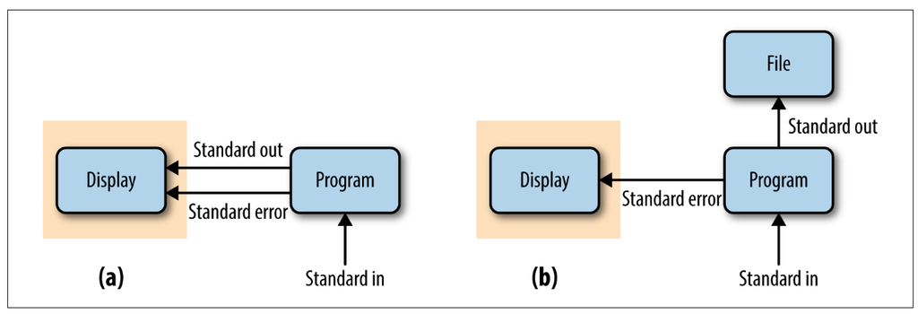

Figure from Buffalo (2015).

To *redirect* the standard error, use **`2>`**[^7]:

```bash
ls solutions/ > solution_files.txt 2> errors.txt
```

To *combine* standard out and standard error, use **`&>`**:

```bash
# (&> out.txt is a Bash shortcut for: > out.txt 2>&1)
ls solutions/ &> out.txt
```

```bash
cat out.txt
```

```
ls: cannot access 'solutions/': No such file or directory
```

Finally, if you want to “manually” turn the output of an `echo` statement in a script **into** standard error instead of standard out, use **`>&2`**. This is good practice for your own error messages, like those in the `if` statements above:

```bash
echo "Error: Invalid line number" >&2
exit 1
```

That way, your error messages behave like those of other programs: for example, they will still be shown on screen when standard out is redirected to a file.

## 8 Shell script *options*

It is also possible to make your shell script accept **options** (as opposed to positional arguments), just like most command-line programs do.

The example below uses both short and long options (e.g. `-o` and `--outdir`). It also uses a mix of “flag”-type options that turn functionality on/off (e.g. `--no-gcbias`) and options that take a value (e.g. `--infile`):

```
scripts/salmon.sh (excerpt)
```

```bash
# Default values (used when an option is not specified)
gcbias=true
outdir=results/salmon

# Process command-line options
while [[ "$#" -gt 0 ]]; do
    case "$1" in
        -i | --infile )     shift && infile="$1" ;;
        -o | --outdir )     shift && outdir="$1" ;;
        --no-gcbias )       gcbias=false ;;
        -v | --version )    echo "Version 2026-10-01" && exit 0 ;;
        * )                 echo "Invalid option $1" >&2 && exit 1 ;;
    esac
    shift
done
```

How this works:

- The `while` loop keeps running as long as there are arguments left (i.e., as long as `$#` is greater than 0).
- In each iteration, `case` compares the current first argument, `$1`, to each pattern (e.g. `-o | --outdir`, where `|` means “or”), and runs the command(s) after the matching pattern, up until `;;`. The final `*` pattern matches anything, so it catches invalid options.
- `shift` removes the first argument, so that the second one becomes `$1`, and so on. Options that take a value, like `--outdir`, have an extra `shift` *inside* the `case` statement, so that `$1` then refers to the option’s value.

Such a script could for example be run like so:

```bash
bash scripts/salmon.sh -i my.bam -o results/salmon --no-gcbias
```

This is more readable and less error-prone than “anonymous” positional arguments, whose order you have to remember. It also makes it easy to have many settings with *defaults* that can be omitted, like `--outdir` and `--no-gcbias` above. In contrast, with positional arguments, only the last one(s) can be made optional.

Back to top

## References

Buffalo, Vince. 2015. *Bioinformatics Data Skills [Reproducible and Robust Research With Open Source Tools]*. First edition. O’Reilly.

## Footnotes

[^1]: The `{01..50}` construct is called brace expansion: the shell expands `sample{01..50}.sam` into the 50 file names `sample01.sam`, `sample02.sam`, …, `sample50.sam` before running `touch`.
[^2]: You can also use single square brackets `[ ]`, but the double brackets have more functionality, and I recommend always using these.
[^3]: The `fi` ending (equivalent to `done` in loops) may seem peculiar, but it is simply “if” in reverse order (you’ll see the same trick with `case` … `esac` further down this page).
[^4]: A single `=` also works but `==` is clearer.
[^5]: You may also see `cat fruits.txt | while read -r ...`, which works for simple cases. But because the loop then runs in a separate “subshell”, any variables you assign inside the loop are lost once the loop finishes.
[^6]: The `-r` option prevents `read` from treating backslashes (`\`) as special characters, and it’s good practice to always use it.
[^7]: Note that `1>` is the full notation to redirect standard out, and the `>` we’ve been using is merely a shortcut for that.